# Group Assignment of Predictive Modeling - Group 8

## Group Members :

### Saurav Suman, Anurag Kedia, Divya Thomas, Neha Tiwary, Peehu

## Question :

- Go through the attached dataset which includes the variable description in detail. Build 2 models based on Support Vector Machines and Discriminant Analysis to predict the customers who will cancel their service and interpret the result and compare the two with each other. Make sure you partition the data set by allocating 70% -for training data and 30% -for validating the results.

## Solution :

### About Dataset:

- The dataset consists of information for 3,333 customers and includes independent variables such as Account weeks,contract renewal ,dataplan, usage, customer service calls, dayMins, daycalls, monthly charges ,overage fee, roaming minutes.
- The dependent variable in the dataset is whether the customer churned or not, which is indicated by a 1 for “yes” and 0 for “no.”
- Below, are the steps we will be following in order to predict customer churn, starting with data preparation and ending with validating the accuracy of our model and finally comparing the results across the models

### Detailed Steps:

### Read the given dataset

```r
mydata <- read.csv(file=file.choose())
head(mydata)
```

|  | Churn | AccountWeeks | ContractRenewal | DataPlan | DataUsage | CustServCalls | DayMins | DayCalls | MonthlyCharge | OverageFee | RoamMins |
| --- | --- | --- | --- | --- | --- | --- | --- | --- | --- | --- | --- |
| 1 | 0 | 128 | 1 | 1 | 2.7 | 1 | 265.1 | 110 | 89 | 9.87 | 10.0 |
| 2 | 0 | 107 | 1 | 1 | 3.7 | 1 | 161.6 | 123 | 82 | 9.78 | 13.7 |
| 3 | 0 | 137 | 1 | 0 | 0.0 | 0 | 243.4 | 114 | 52 | 6.06 | 12.2 |
| 4 | 0 | 84 | 0 | 0 | 0.0 | 2 | 299.4 | 71 | 57 | 3.10 | 6.6 |
| 5 | 0 | 75 | 0 | 0 | 0.0 | 3 | 166.7 | 113 | 41 | 7.42 | 10.1 |
| 6 | 0 | 118 | 0 | 0 | 0.0 | 0 | 223.4 | 98 | 57 | 11.03 | 6.3 |

### View structure of the dataset

```r
str(mydata)
```

```
'data.frame':   3333 obs. of  11 variables:
 $ Churn          : int  0 0 0 0 0 0 0 0 0 0 ...
 $ AccountWeeks   : int  128 107 137 84 75 118 121 147 117 141 ...
 $ ContractRenewal: int  1 1 1 0 0 0 1 0 1 0 ...
 $ DataPlan       : int  1 1 0 0 0 0 1 0 0 1 ...
 $ DataUsage      : num  2.7 3.7 0 0 0 0 2.03 0 0.19 3.02 ...
 $ CustServCalls  : int  1 1 0 2 3 0 3 0 1 0 ...
 $ DayMins        : num  265 162 243 299 167 ...
 $ DayCalls       : int  110 123 114 71 113 98 88 79 97 84 ...
 $ MonthlyCharge  : num  89 82 52 57 41 57 87.3 36 63.9 93.2 ...
 $ OverageFee     : num  9.87 9.78 6.06 3.1 7.42 ...
 $ RoamMins       : num  10 13.7 12.2 6.6 10.1 6.3 7.5 7.1 8.7 11.2 ...
```

### Check for the NA Values in the dataset

```r
sapply(mydata,function(x){sum(is.na(x))})
```

```
          Churn    AccountWeeks ContractRenewal        DataPlan       DataUsage   CustServCalls
              0               0               0               0               0               0
        DayMins        DayCalls   MonthlyCharge      OverageFee        RoamMins
              0               0               0               0               0
```

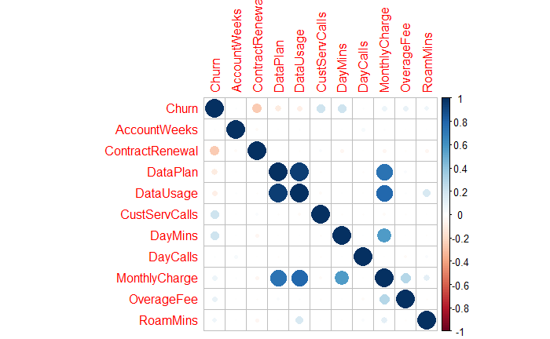

```r
library(corrplot)
corr_re <- cor(mydata)
corrplot(corr_re)
```

### Shapiro-Wilk Test - for the test of normality

```r
#The Shapiro-Wilk test utilizes the null hypothesis principle to check
#whether a sample X1, ..., Xn came from a normally distributed population?
#The null-hypothesis of this test is that the population is normally distributed.

shapiro.test(mydata$AccountWeeks)
```

```
    Shapiro-Wilk normality test

data:  mydata$AccountWeeks
W = 0.99828, p-value = 0.001156
```

```r
shapiro.test(mydata$ContractRenewal)
```

```
    Shapiro-Wilk normality test

data:  mydata$ContractRenewal
W = 0.33606, p-value < 2.2e-16
```

```r
shapiro.test(mydata$DataPlan)
```

```
    Shapiro-Wilk normality test

data:  mydata$DataPlan
W = 0.55961, p-value < 2.2e-16
```

```r
shapiro.test(mydata$DataUsage)
```

```
    Shapiro-Wilk normality test

data:  mydata$DataUsage
W = 0.67226, p-value < 2.2e-16
```

```r
shapiro.test(mydata$CustServCalls)
```

```
    Shapiro-Wilk normality test

data:  mydata$CustServCalls
W = 0.87672, p-value < 2.2e-16
```

```r
shapiro.test(mydata$DayMins)
```

```
    Shapiro-Wilk normality test

data:  mydata$DayMins
W = 0.99954, p-value = 0.6401
```

```r
shapiro.test(mydata$DayCalls)
```

```
    Shapiro-Wilk normality test

data:  mydata$DayCalls
W = 0.99799, p-value = 0.000276
```

```r
shapiro.test(mydata$MonthlyCharge)
```

```
    Shapiro-Wilk normality test

data:  mydata$MonthlyCharge
W = 0.97133, p-value < 2.2e-16
```

```r
shapiro.test(mydata$OverageFee)
```

```
    Shapiro-Wilk normality test

data:  mydata$OverageFee
W = 0.99957, p-value = 0.71
```

```r
shapiro.test(mydata$RoamMins)
```

```
    Shapiro-Wilk normality test

data:  mydata$RoamMins
W = 0.99373, p-value = 7.998e-11
```

### Checking the Assumption of Equal Variance

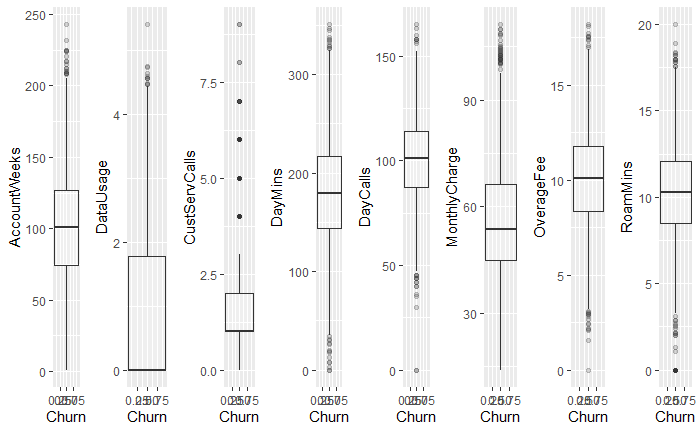

```r
#Checking the Assumption of Equal Variance
#First, in order to get a sense of our data and if we have equal variances among each class, we can use boxplots.

#install.packages("gridExtra"))

library(ggplot2)
library(dplyr)
library(gridExtra)

plot <- list()

box_variables <- c("AccountWeeks", "DataUsage","CustServCalls","DayMins","DayCalls","MonthlyCharge","OverageFee", "RoamMins")
for(i in box_variables) {
  plot[[i]] <- ggplot(mydata, aes_string(x = "Churn", y = i, col = "Churn", fill = "Churn",group = 1)) +
    geom_boxplot(alpha = 0.2) +
    theme(legend.position = "none") +
    scale_color_manual(values = c("blue", "red"))
    scale_fill_manual(values = c("blue", "red"))
}

do.call(grid.arrange, c(plot, nrow = 1))
```

### BoxM test

```r
#We are using the BoxM test in order to check our assumption of homogeneity of variance-covariance matrices.
#H_o = Covariance matrices of the outcome variable are equal across all groups
#H_a = Covariance matrices of the outcome variable are different for at least one group

#install.packages("heplots")
library(heplots)
boxm <- boxM(mydata[, c(5:11, 2)], mydata$Churn) # using columns 1 to 5 and 8
boxm
```

```
    Box's M-test for Homogeneity of Covariance Matrices

data:  mydata[, c(5:11, 2)]
Chi-Sq (approx.) = 533.06, df = 36, p-value < 2.2e-16
```

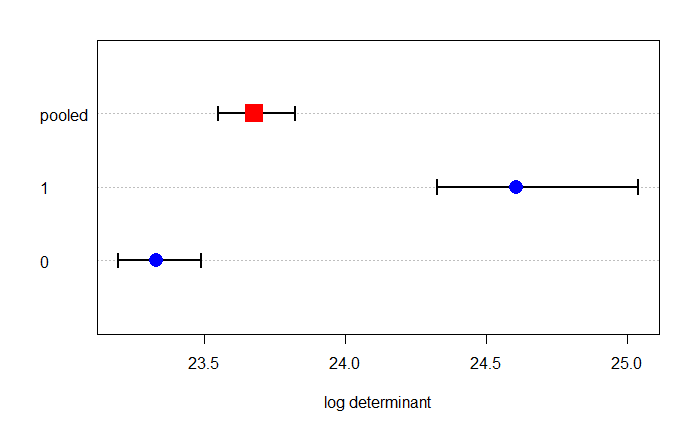

```r
#When are choosing our alpha to be 0.05 then from our result we can conclude that we have a problem of heterogeneity of variance-covariance matrices. The plot below gives information of how the groups differ in the components that go into Box’s M test.

plot(boxm)
```

### QQ Plot - Assumption Checking of LDA vs. QDA – Checking Assumption of Normality

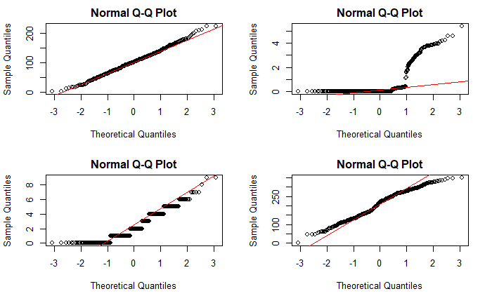

```r
#With the following qqplots, we are checking that the distribution of the predictors is normally distributed within the 2 group .

service_cancle.yes <- subset(mydata, Churn == 1)
service_cancle.no <- subset(mydata, Churn == 0)


variable_1 <- c("AccountWeeks", "DataUsage", "CustServCalls", "DayMins")

## Those we will cancle the service

par(mfrow = c(2, 2))
for(i in variable_1) {
  qqnorm(service_cancle.yes[[i]]); qqline(service_cancle.yes[[i]], col = 2 )
}
```

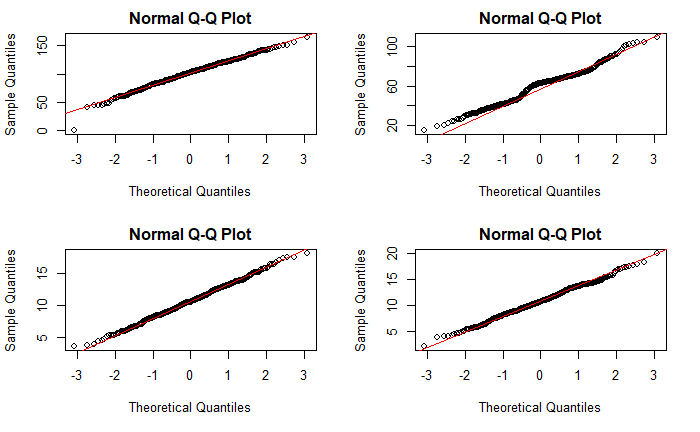

```r
variable_2 <- c("DayCalls", "MonthlyCharge", "OverageFee", "RoamMins")

par(mfrow = c(2, 2))
for(i in variable_2) {
  qqnorm(service_cancle.yes[[i]]); qqline(service_cancle.yes[[i]], col = 2)
}
```

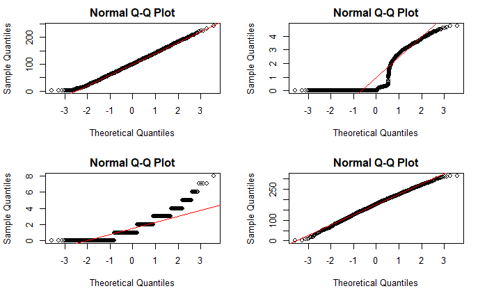

```r
## Those we will not cancle the service

par(mfrow = c(2, 2))
for(i in variable_1) {
  qqnorm(service_cancle.no[[i]]); qqline(service_cancle.no[[i]], col = 2 )
}
```

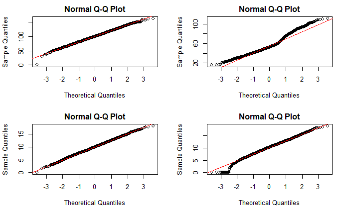

```r
par(mfrow = c(2, 2))
for(i in variable_2) {
  qqnorm(service_cancle.no[[i]]); qqline(service_cancle.no[[i]], col = 2)
}
```

### Density Plot of Numerical Variables

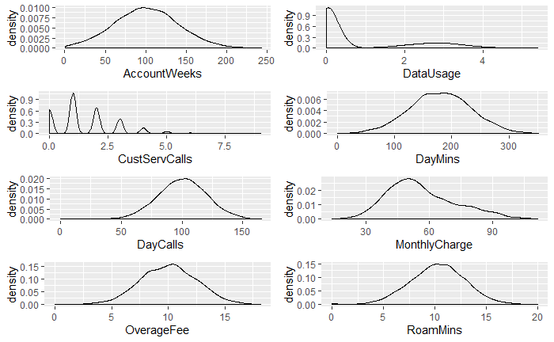

```r
#Another visualization technique is to plot the density of the predictors for each group. Through the plots below, we can detect if the predictors in each group are normally distributed and we can also check for equal variance.

plot <- list()
for(i in names(mydata)[-c(1,3,4)]){
  plot[[i]] <- ggplot(mydata, aes_string(x = i, y = "..density..", col = "Churn")) +
    geom_density(aes(y = ..density..)) +
    scale_color_manual(values = c("blue", "red")) +
    theme(legend.position = "none")
}

do.call(grid.arrange, c(plot, nrow = 4))
```

### Histogram

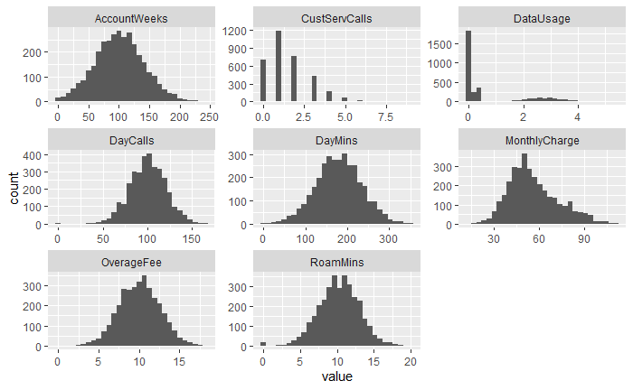

```r
#install.packages("purrr")
library(purrr)
library(tidyr)
library(ggplot2)
mydata[-c(1,3,4)] %>%
  keep(is.numeric) %>%
  gather() %>%
  ggplot(aes(value)) +
    facet_wrap(~ key, scales = "free") +
    geom_histogram()
```

```r
head(mydata)
```

|  | Churn | AccountWeeks | ContractRenewal | DataPlan | DataUsage | CustServCalls | DayMins | DayCalls | MonthlyCharge | OverageFee | RoamMins |
| --- | --- | --- | --- | --- | --- | --- | --- | --- | --- | --- | --- |
| 1 | 0 | 128 | 1 | 1 | 2.7 | 1 | 265.1 | 110 | 89 | 9.87 | 10.0 |
| 2 | 0 | 107 | 1 | 1 | 3.7 | 1 | 161.6 | 123 | 82 | 9.78 | 13.7 |
| 3 | 0 | 137 | 1 | 0 | 0.0 | 0 | 243.4 | 114 | 52 | 6.06 | 12.2 |
| 4 | 0 | 84 | 0 | 0 | 0.0 | 2 | 299.4 | 71 | 57 | 3.10 | 6.6 |
| 5 | 0 | 75 | 0 | 0 | 0.0 | 3 | 166.7 | 113 | 41 | 7.42 | 10.1 |
| 6 | 0 | 118 | 0 | 0 | 0.0 | 0 | 223.4 | 98 | 57 | 11.03 | 6.3 |

### Convert target variable Churn into categorial variable

```r
mydata$Churn <- as.factor(mydata$Churn)

str(mydata)
```

```
'data.frame':   3333 obs. of  11 variables:
 $ Churn          : Factor w/ 2 levels "0","1": 1 1 1 1 1 1 1 1 1 1 ...
 $ AccountWeeks   : int  128 107 137 84 75 118 121 147 117 141 ...
 $ ContractRenewal: int  1 1 1 0 0 0 1 0 1 0 ...
 $ DataPlan       : int  1 1 0 0 0 0 1 0 0 1 ...
 $ DataUsage      : num  2.7 3.7 0 0 0 0 2.03 0 0.19 3.02 ...
 $ CustServCalls  : int  1 1 0 2 3 0 3 0 1 0 ...
 $ DayMins        : num  265 162 243 299 167 ...
 $ DayCalls       : int  110 123 114 71 113 98 88 79 97 84 ...
 $ MonthlyCharge  : num  89 82 52 57 41 57 87.3 36 63.9 93.2 ...
 $ OverageFee     : num  9.87 9.78 6.06 3.1 7.42 ...
 $ RoamMins       : num  10 13.7 12.2 6.6 10.1 6.3 7.5 7.1 8.7 11.2 ...
```

### Scale the dataset

```r
library(scales)

mydata_s <- scale(mydata[,-1])
mydata_s = as.data.frame(mydata_s)

head(mydata_s)
```

|  | AccountWeeks | ContractRenewal | DataPlan | DataUsage | CustServCalls | DayMins | DayCalls | MonthlyCharge | OverageFee | RoamMins |
| --- | --- | --- | --- | --- | --- | --- | --- | --- | --- | --- |
| 1 | 0.6763880 | 0.3275313 | 1.6168435 | 1.4799817 | -0.4278678 | 1.5665319 | 0.4765716 | 1.99042837 | -0.07157286 | -0.08499548 |
| 2 | 0.1490427 | 0.3275313 | 1.6168435 | 2.2657325 | -0.4278678 | -0.3336877 | 1.1243341 | 1.56427553 | -0.10706585 | 1.24029559 |
| 3 | 0.9023931 | 0.3275313 | -0.6183035 | -0.6415457 | -1.1880402 | 1.1681284 | 0.6758832 | -0.26209377 | -1.57410948 | 0.70301543 |
| 4 | -0.4285260 | -3.0522270 | -0.6183035 | -0.6415457 | 0.3323046 | 2.1962665 | -1.4667158 | 0.04230112 | -2.74143452 | -1.30283051 |
| 5 | -0.6545311 | -3.0522270 | -0.6183035 | -0.6415457 | 1.0924770 | -0.2400537 | 0.6260553 | -0.93176251 | -1.03777095 | -0.04917680 |
| 6 | 0.4252712 | -3.0522270 | -0.6183035 | -0.6415457 | -1.1880402 | 0.8009362 | -0.1213630 | 0.04230112 | 0.38589236 | -1.41028654 |

```r
NA
```

### Combine the Target variable “Churn” with rest of the predictor variables

```r
Churn <- mydata$Churn
mydata_s_final <- cbind(mydata_s,Churn)

head(mydata_s_final)
```

|  | AccountWeeks | ContractRenewal | DataPlan | DataUsage | CustServCalls | DayMins | DayCalls | MonthlyCharge | OverageFee | RoamMins | Churn |
| --- | --- | --- | --- | --- | --- | --- | --- | --- | --- | --- | --- |
| 1 | 0.6763880 | 0.3275313 | 1.6168435 | 1.4799817 | -0.4278678 | 1.5665319 | 0.4765716 | 1.99042837 | -0.07157286 | -0.08499548 | 0 |
| 2 | 0.1490427 | 0.3275313 | 1.6168435 | 2.2657325 | -0.4278678 | -0.3336877 | 1.1243341 | 1.56427553 | -0.10706585 | 1.24029559 | 0 |
| 3 | 0.9023931 | 0.3275313 | -0.6183035 | -0.6415457 | -1.1880402 | 1.1681284 | 0.6758832 | -0.26209377 | -1.57410948 | 0.70301543 | 0 |
| 4 | -0.4285260 | -3.0522270 | -0.6183035 | -0.6415457 | 0.3323046 | 2.1962665 | -1.4667158 | 0.04230112 | -2.74143452 | -1.30283051 | 0 |
| 5 | -0.6545311 | -3.0522270 | -0.6183035 | -0.6415457 | 1.0924770 | -0.2400537 | 0.6260553 | -0.93176251 | -1.03777095 | -0.04917680 | 0 |
| 6 | 0.4252712 | -3.0522270 | -0.6183035 | -0.6415457 | -1.1880402 | 0.8009362 | -0.1213630 | 0.04230112 | 0.38589236 | -1.41028654 | 0 |

```r
NA
```

```r
str(mydata_s_final)
```

```
'data.frame':   3333 obs. of  11 variables:
 $ AccountWeeks   : num  0.676 0.149 0.902 -0.429 -0.655 ...
 $ ContractRenewal: num  0.328 0.328 0.328 -3.052 -3.052 ...
 $ DataPlan       : num  1.617 1.617 -0.618 -0.618 -0.618 ...
 $ DataUsage      : num  1.48 2.266 -0.642 -0.642 -0.642 ...
 $ CustServCalls  : num  -0.428 -0.428 -1.188 0.332 1.092 ...
 $ DayMins        : num  1.567 -0.334 1.168 2.196 -0.24 ...
 $ DayCalls       : num  0.477 1.124 0.676 -1.467 0.626 ...
 $ MonthlyCharge  : num  1.9904 1.5643 -0.2621 0.0423 -0.9318 ...
 $ OverageFee     : num  -0.0716 -0.1071 -1.5741 -2.7414 -1.0378 ...
 $ RoamMins       : num  -0.085 1.2403 0.703 -1.3028 -0.0492 ...
 $ Churn          : Factor w/ 2 levels "0","1": 1 1 1 1 1 1 1 1 1 1 ...
```

### Split the dataset into 70:30 ration as train and test data

```r
library(caTools)

set.seed(420)
## split into training and test sets
split = sample.split(mydata_s_final$Churn, SplitRatio = 0.7)

# Create train and test set
traindata = subset(mydata_s_final, split == TRUE)
testdata = subset(mydata_s_final, split == FALSE)

# Proportion of Table
prop.table(table(traindata$Churn))
```

```
        0         1
0.8551222 0.1448778
```

```r
prop.table(table(testdata$Churn))
```

```
    0     1
0.855 0.145
```

### Build the LDA model using Fisher desDA function

```r
library(DiscriMiner)

xtrain <- traindata[,1:10]
ytrain <- traindata[,11]

xtest <- testdata[,1:10]
ytest <- testdata[,11]

Fisher <- desDA(xtrain,ytrain)
Fisher
```

```
Descriptive Discriminant Analysis
---------------------------------
$power      discriminant power
$values     table of eigenvalues
$discrivar  discriminant variables
$discor     correlations
$scores     discriminant scores
---------------------------------

$power
                 cor_ratio       wilks_lamb      F_statistic     p_values
AccountWeeks       0.0000101382    0.9999898618    0.0236323197    0.8778374578
ContractRenewal    0.0698099350    0.9301900650  174.9394715783    0.0000000000
DataPlan           0.0118285623    0.9881714377   27.9024242792    0.0000001394
DataUsage          0.0085419005    0.9914580995   20.0827146578    0.0000077750
CustServCalls      0.0427226046    0.9572773954  104.0308605427    0.0000000000
DayMins            0.0404577641    0.9595422359   98.2833737775    0.0000000000
DayCalls           0.0006080242    0.9993919758    1.4181666582    0.2338266493
MonthlyCharge      0.0042685906    0.9957314094    9.9927395904    0.0015917685
OverageFee         0.0082400384    0.9917599616   19.3671153192    0.0000112707
RoamMins           0.0041328223    0.9958671777    9.6735880437    0.0018919692


$values
     value    proportion  accumulated
DF1    0.187  100.000     100.000


$discrivar
                       DF1
constant          0.003332
AccountWeeks     -0.030856
ContractRenewal  -0.674472
DataPlan         -0.251586
DataUsage         1.154119
CustServCalls     0.571180
DayMins           1.376119
DayCalls          0.055117
MonthlyCharge    -1.552931
OverageFee        0.627555
RoamMins          0.152026


$discor
                       DF1
AccountWeeks     -0.007602
ContractRenewal  -0.630817
DataPlan         -0.259663
DataUsage        -0.220659
CustServCalls     0.493484
DayMins           0.480226


$scores
        z1
1  -0.1484
3  -0.3381
4   2.6375
7   0.7681
8   0.6669
9   0.2845
...
```

### Build the model using Mahalanobis on train data

```r
Mahalanobis_Model_Train <- linDA(xtrain,ytrain)

Mahalanobis_Model_Train
```

```
Linear Discriminant Analysis
-------------------------------------------
$functions        discrimination functions
$confusion        confusion matrix
$scores           discriminant scores
$classification   assigned class
$error_rate       error rate
-------------------------------------------

$functions
                 0         1
constant         -0.17618  -2.55651
AccountWeeks      0.02386  -0.01656
ContractRenewal   0.12225  -0.76125
DataPlan         -0.03759  -0.36714
DataUsage         0.28605   1.79784
CustServCalls    -0.10851   0.63968
DayMins           0.03181   1.83440
DayCalls         -0.00415   0.06805
MonthlyCharge    -0.24547  -2.27967
OverageFee        0.02762   0.84966
RoamMins         -0.07125   0.12789


$confusion
        predicted
original     0     1
       0  1905    90
       1   259    79


$error_rate
[1] 0.1495928


$scores
            0           1
1  -0.1476667  -2.7267134
3  -0.1408470  -2.9684020
4  -0.6731916   0.3969578
7  -0.3187193  -1.6972847
8  -0.2317819  -1.7428955
9  -0.1865347  -2.1985135
...

$classification
[1] 0 0 1 0 0 0
Levels: 0 1
...
```

### Performance Measure on train data using Mahalanobis LDA Model

```r
tabtrain <- Mahalanobis_Model_Train$confusion

tabtrain
```

```
        predicted
original    0    1
       0 1905   90
       1  259   79
```

```r
TN_train = tabtrain[1,1]
TP_train = tabtrain[2,2]
FN_train = tabtrain[2,1]
FP_train = tabtrain[1,2]

# Accuracy
train_acc_lda = (TN_train+TP_train)/(TN_train+TP_train+FN_train+FP_train)
train_acc_lda
```

```
[1] 0.8504072
```

```r
# Sensitivity
train_sens_lda = TP_train/(TP_train+FN_train)
train_sens_lda
```

```
[1] 0.2337278
```

```r
# Specificity
train_spec_lda = TN_train/(TN_train+FP_train)
train_spec_lda
```

```
[1] 0.9548872
```

### Build the model using Mahalanobis on test data

```r
Mahalanobis_Model_Test <- linDA(xtest,ytest)

Mahalanobis_Model_Test
```

```
Linear Discriminant Analysis
-------------------------------------------
$functions        discrimination functions
$confusion        confusion matrix
$scores           discriminant scores
$classification   assigned class
$error_rate       error rate
-------------------------------------------

$functions
                 0        1
constant         -0.1790  -2.5976
AccountWeeks     -0.0738   0.1156
ContractRenewal   0.1360  -0.7072
DataPlan          0.1877   0.3594
DataUsage        -0.8099  -5.4204
CustServCalls    -0.1105   0.6520
DayMins          -0.5547  -2.8620
DayCalls         -0.0184   0.0367
MonthlyCharge     0.8599   6.2359
OverageFee       -0.2945  -1.3190
RoamMins          0.0568   0.3955


$confusion
        predicted
original    0    1
       0  818   37
       1  106   39


$error_rate
[1] 0.143


$scores
              0           1
2   -0.01813785  -3.4085376
5   -0.63951676  -0.2981546
6   -0.69004393  -1.0088546
11  -0.27772525  -1.6744327
13  -0.03184845  -3.9612376
18  -0.38131020  -2.1977603
...

$classification
[1] 0 1 0 0 0 0
Levels: 0 1
...
```

### Performance Measure on test data using Mahalanobis LDA Model

```r
tabtrain <- Mahalanobis_Model_Test$confusion

tabtrain
```

```
        predicted
original   0   1
       0 818  37
       1 106  39
```

```r
TN_train = tabtrain[1,1]
TP_train = tabtrain[2,2]
FN_train = tabtrain[2,1]
FP_train = tabtrain[1,2]

# Accuracy
train_acc_lda = (TN_train+TP_train)/(TN_train+TP_train+FN_train+FP_train)
train_acc_lda
```

```
[1] 0.857
```

```r
# Sensitivity
train_sens_lda = TP_train/(TP_train+FN_train)
train_sens_lda
```

```
[1] 0.2689655
```

```r
# Specificity
train_spec_lda = TN_train/(TN_train+FP_train)
train_spec_lda
```

```
[1] 0.9567251
```

### Build the LDA model using lda function on train data

```r
library(MASS)

model_lda <- lda(traindata$Churn ~ . , traindata)

model_lda
```

```
Call:
lda(traindata$Churn ~ ., data = traindata)

Prior probabilities of groups:
        0         1
0.8551222 0.1448778

Group means:
  AccountWeeks ContractRenewal    DataPlan   DataUsage CustServCalls     DayMins     DayCalls MonthlyCharge
0   0.02074025       0.1039082  0.04047668  0.03638995   -0.08417082 -0.09331117 -0.004573398   -0.03302403
1   0.01174568      -0.6523986 -0.26782186 -0.22626005    0.49873287  0.47709005  0.066597248    0.15278385
   OverageFee    RoamMins
0 -0.03265807 -0.05429375
1  0.22898580  0.12747922

Coefficients of linear discriminants:
                        LD1
AccountWeeks    -0.03085589
ContractRenewal -0.67447234
DataPlan        -0.25158583
DataUsage        1.15411887
CustServCalls    0.57118024
DayMins          1.37611940
DayCalls         0.05511706
MonthlyCharge   -1.55293051
OverageFee       0.62755513
RoamMins         0.15202564
```

### Plotting the train data using the basic plot function illustrates how the observations are grouped together.

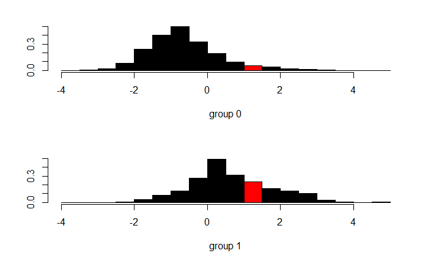

```r
plot(model_lda, col = as.integer(traindata$Churn))
```

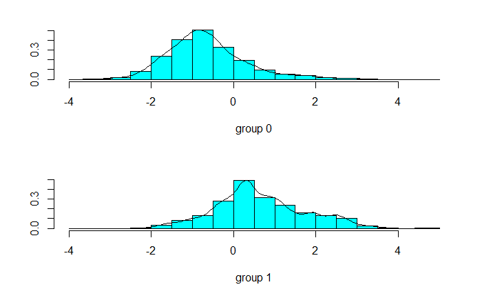

```r
plot(model_lda, dimen=1, type="both")
```

### Predict on train data using the above LDA model

```r
lda.train <- predict(model_lda)

traindata$predict.class=lda.train$class

traindata$predict.posterior=lda.train$posterior


## Creating the confusion matrix
tabtrain=with(traindata,table(Churn,predict.class))
tabtrain
```

```
     predict.class
Churn    0    1
    0 1905   90
    1  259   79
```

```r
TN_train = tabtrain[1,1]
TP_train = tabtrain[2,2]
FN_train = tabtrain[2,1]
FP_train = tabtrain[1,2]

# Accuracy
train_acc_lda = (TN_train+TP_train)/(TN_train+TP_train+FN_train+FP_train)
train_acc_lda
```

```
[1] 0.8504072
```

```r
#Sensivity
train_sens_lda = TP_train/(TP_train+FN_train)
train_sens_lda
```

```
[1] 0.2337278
```

```r
#Specificity
train_spec_lda = TN_train/(TN_train+FP_train)
train_spec_lda
```

```
[1] 0.9548872
```

### Predict on test data using above LDA model

```r
lda.test <- predict(model_lda,testdata)

testdata$predict.class=lda.test$class

testdata$predict.posterior=lda.test$posterior


## Creating the confusion matrix
tabtest=with(testdata,table(Churn,predict.class))
tabtest
```

```
     predict.class
Churn   0   1
    0 817  38
    1 108  37
```

```r
TN_test = tabtest[1,1]
TP_test = tabtest[2,2]
FN_test = tabtest[2,1]
FP_test = tabtest[1,2]

#Accuracy
test_acc_lda = (TN_test+TP_test)/(TN_test+TP_test+FN_test+FP_test)
test_acc_lda
```

```
[1] 0.854
```

```r
#Sensivity
test_sens_lda = TP_test/(TP_test+FN_test)
test_sens_lda
```

```
[1] 0.2551724
```

```r
#Specificity
test_spec_lda = TN_test/(TN_test+FP_test)
test_spec_lda
```

```
[1] 0.9555556
```

### Draw the AUC-ROC Curve of LDA model with train and test data

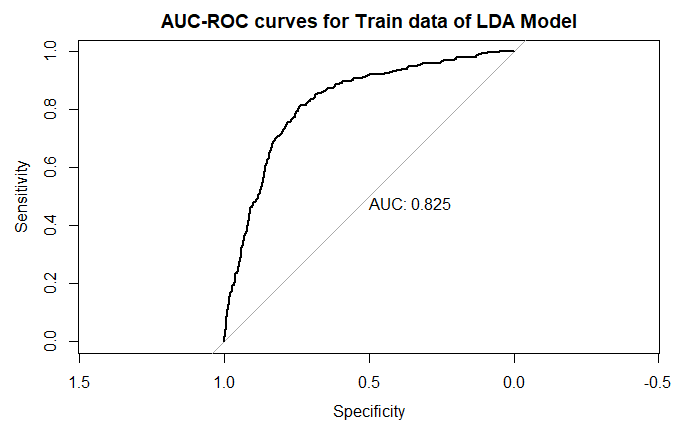

```r
library(pROC)
#Train data

roc_obj_train_lda = roc(traindata$Churn, traindata$predict.posterior[,2])
plot(roc_obj_train_lda, print.auc = T,main = "AUC-ROC curves for Train data of LDA Model")
```

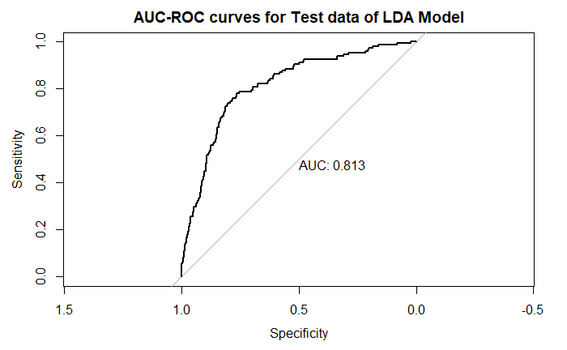

```r
#Test data

roc_obj_test_lda = roc(testdata$Churn, testdata$predict.posterior[,2])
plot(roc_obj_test_lda, print.auc = T,main = "AUC-ROC curves for Test data of LDA Model")
```

```r
#Combines AUC-ROC Curve of LDA train and test

plot(roc_obj_train_lda, main = "Combined AUC-ROC curves for Train and Test for LDA Model", col='blue',xlab = "1 - Specificity")
plot(roc_obj_test_lda,add=TRUE, col='red')
```

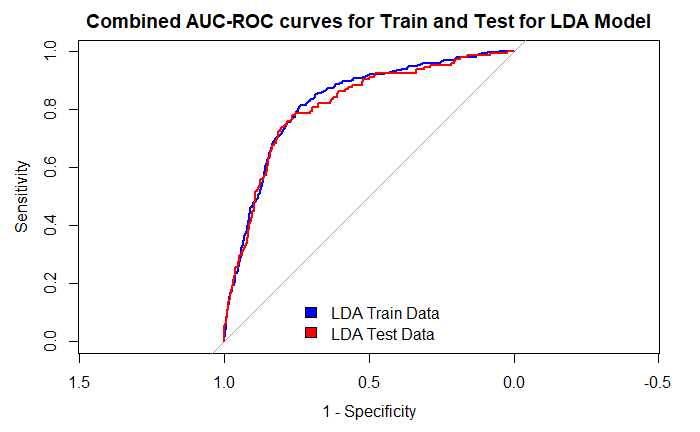

```r
legend('bottom', c("LDA Train Data", "LDA Test Data" ), fill = c('blue','red'), bty='n')
```

### Comparison of all performace measure of LDA model

```r
results_train_lda = data.frame(train_acc_lda, train_sens_lda, train_spec_lda , as.numeric(roc_obj_train_lda$auc))
names(results_train_lda) = c("ACCURACY", "SENSITIVITY", "SPECIFICITY" , "AUC-ROC" )
results_test_lda = data.frame(test_acc_lda, test_sens_lda, test_spec_lda ,as.numeric(roc_obj_test_lda$auc) )
names(results_test_lda) = c("ACCURACY", "SENSITIVITY", "SPECIFICITY" , "AUC-ROC")


df_fin =rbind(results_train_lda, results_test_lda)
row.names(df_fin) = c('LDA_train', 'LDA_test')
df_fin
```

|  | ACCURACY | SENSITIVITY | SPECIFICITY | AUC-ROC |
| --- | --- | --- | --- | --- |
| LDA_train | 0.8504072 | 0.2337278 | 0.9548872 | 0.8252851 |
| LDA_test | 0.8540000 | 0.2551724 | 0.9555556 | 0.8128171 |

```r
NA
NA
```

### Remove predicted score and class before running other models

```r
traindata$predict.class = NULL
traindata$predict.posterior = NULL
testdata$predict.class = NULL
testdata$predict.posterior = NULL
```

```r
head(traindata)
```

|  | AccountWeeks | ContractRenewal | DataPlan | DataUsage | CustServCalls | DayMins | DayCalls | MonthlyCharge | OverageFee | RoamMins | Churn |
| --- | --- | --- | --- | --- | --- | --- | --- | --- | --- | --- | --- |
| 1 | 0.6763880 | 0.3275313 | 1.6168435 | 1.4799817 | -0.4278678 | 1.56653190 | 0.4765716 | 1.99042837 | -0.07157286 | -0.08499548 | 0 |
| 3 | 0.9023931 | 0.3275313 | -0.6183035 | -0.6415457 | -1.1880402 | 1.16812837 | 0.6758832 | -0.26209377 | -1.57410948 | 0.70301543 | 0 |
| 4 | -0.4285260 | -3.0522270 | -0.6183035 | -0.6415457 | 0.3323046 | 2.19626650 | -1.4667158 | 0.04230112 | -2.74143452 | -1.30283051 | 0 |
| 7 | 0.5006062 | 0.3275313 | 1.6168435 | 0.9535286 | 1.0924770 | 0.70546621 | -0.6196418 | 1.88693411 | 2.90983839 | -0.98046241 | 0 |
| 8 | 1.1535099 | -3.0522270 | -0.6183035 | -0.6415457 | -1.1880402 | -0.41814190 | -1.0680928 | -1.23615739 | -1.92903939 | -1.12373712 | 0 |
| 9 | 0.4001595 | 0.3275313 | -0.6183035 | -0.4922530 | -0.4278678 | 0.08674736 | -0.1711908 | 0.46236606 | 2.96899337 | -0.55063828 | 0 |

```r
mydata$ContractRenewal <- as.factor(mydata$ContractRenewal)
mydata$DataPlan <- as.factor(mydata$DataPlan)

str(mydata)
```

```
'data.frame':   3333 obs. of  11 variables:
 $ Churn          : Factor w/ 2 levels "0","1": 1 1 1 1 1 1 1 1 1 1 ...
 $ AccountWeeks   : int  128 107 137 84 75 118 121 147 117 141 ...
 $ ContractRenewal: Factor w/ 2 levels "0","1": 2 2 2 1 1 1 2 1 2 1 ...
 $ DataPlan       : Factor w/ 2 levels "0","1": 2 2 1 1 1 1 2 1 1 2 ...
 $ DataUsage      : num  2.7 3.7 0 0 0 0 2.03 0 0.19 3.02 ...
 $ CustServCalls  : int  1 1 0 2 3 0 3 0 1 0 ...
 $ DayMins        : num  265 162 243 299 167 ...
 $ DayCalls       : int  110 123 114 71 113 98 88 79 97 84 ...
 $ MonthlyCharge  : num  89 82 52 57 41 57 87.3 36 63.9 93.2 ...
 $ OverageFee     : num  9.87 9.78 6.06 3.1 7.42 ...
 $ RoamMins       : num  10 13.7 12.2 6.6 10.1 6.3 7.5 7.1 8.7 11.2 ...
```

### Split the dataset into 70:30 ration as train and test data

```r
library(caTools)

set.seed(420)
## split into training and test sets
split = sample.split(mydata$Churn, SplitRatio = 0.7)

# Create train and test set
train = subset(mydata_s_final, split == TRUE)
test = subset(mydata_s_final, split == FALSE)

# Proportion of Table
prop.table(table(traindata$Churn))
```

```
        0         1
0.8551222 0.1448778
```

```r
prop.table(table(testdata$Churn))
```

```
    0     1
0.855 0.145
```

### Create task for MLR

```r
library(mlr)
trainTask = makeClassifTask(data = train,target = "Churn", positive = "1")
testTask = makeClassifTask(data = test, target = "Churn", positive = "1")

trainTask
```

```
Supervised task: train
Type: classif
Target: Churn
Observations: 2333
Features:
   numerics     factors     ordered functionals
         10           0           0           0
Missings: FALSE
Has weights: FALSE
Has blocking: FALSE
Has coordinates: FALSE
Classes: 2
   0    1
1995  338
Positive class: 1
```

```r
#normalize the variables***** NEW*****
trainTask = normalizeFeatures(trainTask,method = "standardize")
testTask = normalizeFeatures(testTask,method = "standardize")
```

### Build LDA Model using MLR Package

```r
library(caret)
lda.learner = makeLearner("classif.lda", predict.type = "prob")

lda.model = mlr::train(lda.learner, trainTask)
```

### Predict on train data using above model

```r
lda.predict.train = predict(lda.model, trainTask)


tabtrain = confusionMatrix(lda.predict.train$data$truth,lda.predict.train$data$response , positive = "1")

tabtrain
```

```
Confusion Matrix and Statistics

          Reference
Prediction    0    1
         0 1905   90
         1  259   79

               Accuracy : 0.8504
                 95% CI : (0.8353, 0.8646)
    No Information Rate : 0.9276
    P-Value [Acc > NIR] : 1

                  Kappa : 0.238

 Mcnemar's Test P-Value : <2e-16

            Sensitivity : 0.46746
            Specificity : 0.88031
         Pos Pred Value : 0.23373
         Neg Pred Value : 0.95489
             Prevalence : 0.07244
         Detection Rate : 0.03386
   Detection Prevalence : 0.14488
      Balanced Accuracy : 0.67388

       'Positive' Class : 1
```

```r
TN_train = tabtrain$table[1,1]
TP_train = tabtrain$table[2,2]
FN_train = tabtrain$table[1,2]
FP_train = tabtrain$table[2,1]

# Accuracy
train_acc_ldamlr = (TN_train+TP_train)/(TN_train+TP_train+FN_train+FP_train)
train_acc_ldamlr
```

```
[1] 0.8504072
```

```r
#Sensivity
train_sens_ldamlr = TP_train/(TP_train+FN_train)
train_sens_ldamlr
```

```
[1] 0.4674556
```

```r
#Specificity
train_spec_ldamlr = TN_train/(TN_train+FP_train)
train_spec_ldamlr
```

```
[1] 0.8803142
```

### Predict on test data using above model

```r
lda.predict.test = predict(lda.model, testTask)

tabtest = confusionMatrix(lda.predict.test$data$truth,lda.predict.test$data$response , positive = "1")
tabtest
```

```
Confusion Matrix and Statistics

          Reference
Prediction   0   1
         0 813  42
         1 108  37

               Accuracy : 0.85
                 95% CI : (0.8263, 0.8716)
    No Information Rate : 0.921
    P-Value [Acc > NIR] : 1

                  Kappa : 0.2541

 Mcnemar's Test P-Value : 1.113e-07

            Sensitivity : 0.4684
            Specificity : 0.8827
         Pos Pred Value : 0.2552
         Neg Pred Value : 0.9509
             Prevalence : 0.0790
         Detection Rate : 0.0370
   Detection Prevalence : 0.1450
      Balanced Accuracy : 0.6755

       'Positive' Class : 1
```

```r
TN_test = tabtest$table[1,1]
TP_test = tabtest$table[2,2]
FN_test = tabtest$table[1,2]
FP_test = tabtest$table[2,1]

# Accuracy
test_acc_ldamlr = (TN_test+TP_test)/(TN_test+TP_test+FN_test+FP_test)
test_acc_ldamlr
```

```
[1] 0.85
```

```r
#Sensivity
test_sens_ldamlr = TP_test/(TP_test+FN_test)
test_sens_ldamlr
```

```
[1] 0.4683544
```

```r
#Specificity
test_spec_ldamlr = TN_test/(TN_test+FP_test)
test_spec_ldamlr
```

```
[1] 0.8827362
```

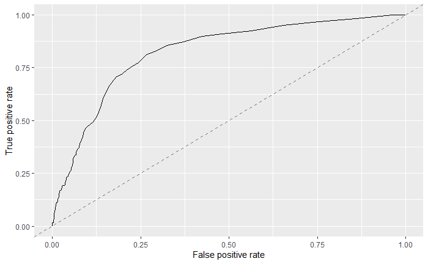

```r
library(ROCR)

#Train data

roc_obj_train_ldamlr = generateThreshVsPerfData(lda.predict.train, measures = list(fpr, tpr, mmce))
plotROCCurves(roc_obj_train_ldamlr)
```

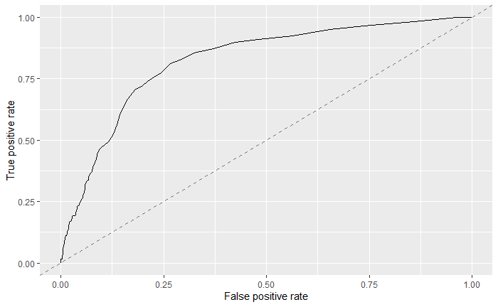

```r
#Test data

roc_obj_test_ldamlr = generateThreshVsPerfData(lda.predict.test, measures = list(fpr, tpr, mmce))
plotROCCurves(roc_obj_train_ldamlr)
```

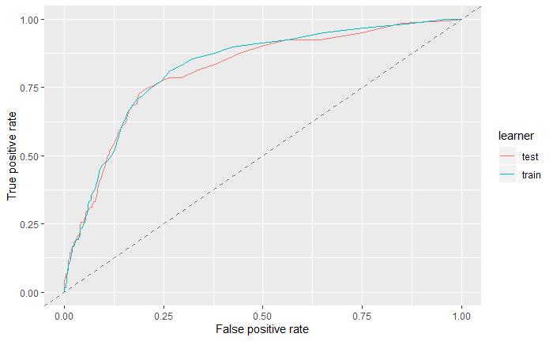

```r
#Combines AUC-ROC Curve of QDA train and test

df = generateThreshVsPerfData(list(train = lda.predict.train, test = lda.predict.test), measures = list(fpr, tpr))
plotROCCurves(df)
```

### Comparison of all performace measure above of LDA model

```r
results_train_ldamlr = data.frame(train_acc_ldamlr, train_sens_ldamlr, train_spec_ldamlr,as.numeric(mlr::performance(lda.predict.train, mlr::auc)))
names(results_train_ldamlr) = c("ACCURACY", "SENSITIVITY", "SPECIFICITY", "AUC-ROC")
results_test_ldamlr = data.frame(test_acc_ldamlr, test_sens_ldamlr, test_spec_ldamlr,as.numeric(mlr::performance(lda.predict.train, mlr::auc)) )
names(results_test_ldamlr) = c("ACCURACY", "SENSITIVITY", "SPECIFICITY" , "AUC-ROC")


df_fin =rbind(results_train_ldamlr, results_test_ldamlr)
row.names(df_fin) = c('LDA_train', 'LDA_test')
df_fin
```

|  | ACCURACY | SENSITIVITY | SPECIFICITY | AUC-ROC |
| --- | --- | --- | --- | --- |
| LDA_train | 0.8504072 | 0.4674556 | 0.8803142 | 0.8252851 |
| LDA_test | 0.8500000 | 0.4683544 | 0.8827362 | 0.8252851 |

```r
NA
```

### Build QDA Model using MLR Package

```r
qda.learner = makeLearner("classif.qda", predict.type = "prob")

qda.model = mlr::train(qda.learner, trainTask)
```

### Predict on train data using above model

```r
qda.predict.train = predict(qda.model, trainTask)

tabtrain = table(qda.predict.train$data$truth,qda.predict.train$data$response)


tabtrain = confusionMatrix(qda.predict.train$data$truth,qda.predict.train$data$response , positive = "1")

tabtrain
```

```
Confusion Matrix and Statistics

          Reference
Prediction    0    1
         0 1847  148
         1  170  168

               Accuracy : 0.8637
                 95% CI : (0.8491, 0.8774)
    No Information Rate : 0.8646
    P-Value [Acc > NIR] : 0.5629

                  Kappa : 0.4346

 Mcnemar's Test P-Value : 0.2389

            Sensitivity : 0.53165
            Specificity : 0.91572
         Pos Pred Value : 0.49704
         Neg Pred Value : 0.92581
             Prevalence : 0.13545
         Detection Rate : 0.07201
   Detection Prevalence : 0.14488
      Balanced Accuracy : 0.72368

       'Positive' Class : 1
```

```r
TN_train = tabtrain$table[1,1]
TP_train = tabtrain$table[2,2]
FN_train = tabtrain$table[1,2]
FP_train = tabtrain$table[2,1]

# Accuracy
train_acc_qdamlr = (TN_train+TP_train)/(TN_train+TP_train+FN_train+FP_train)
train_acc_qdamlr
```

```
[1] 0.8636948
```

```r
#Sensivity
train_sens_qdamlr = TP_train/(TP_train+FN_train)
train_sens_qdamlr
```

```
[1] 0.5316456
```

```r
#Specificity
train_spec_qdamlr = TN_train/(TN_train+FP_train)
train_spec_qdamlr
```

```
[1] 0.9157164
```

### Predict on test data using above model

```r
qda.predict.test = predict(qda.model, testTask)

tabtest = confusionMatrix(qda.predict.test$data$truth,qda.predict.test$data$response , positive = "1")
tabtest
```

```
Confusion Matrix and Statistics

          Reference
Prediction   0   1
         0 793  62
         1  72  73

               Accuracy : 0.866
                 95% CI : (0.8433, 0.8865)
    No Information Rate : 0.865
    P-Value [Acc > NIR] : 0.4860

                  Kappa : 0.4436

 Mcnemar's Test P-Value : 0.4369

            Sensitivity : 0.5407
            Specificity : 0.9168
         Pos Pred Value : 0.5034
         Neg Pred Value : 0.9275
             Prevalence : 0.1350
         Detection Rate : 0.0730
   Detection Prevalence : 0.1450
      Balanced Accuracy : 0.7288

       'Positive' Class : 1
```

```r
TN_test = tabtest$table[1,1]
TP_test = tabtest$table[2,2]
FN_test = tabtest$table[1,2]
FP_test = tabtest$table[2,1]

# Accuracy
test_acc_qdamlr = (TN_test+TP_test)/(TN_test+TP_test+FN_test+FP_test)
test_acc_qdamlr
```

```
[1] 0.866
```

```r
#Sensivity
test_sens_qdamlr = TP_test/(TP_test+FN_test)
test_sens_qdamlr
```

```
[1] 0.5407407
```

```r
#Specificity
test_spec_qdamlr = TN_test/(TN_test+FP_test)
test_spec_qdamlr
```

```
[1] 0.916763
```

### Draw the AUC-ROC Curve of QDA model with train and test data

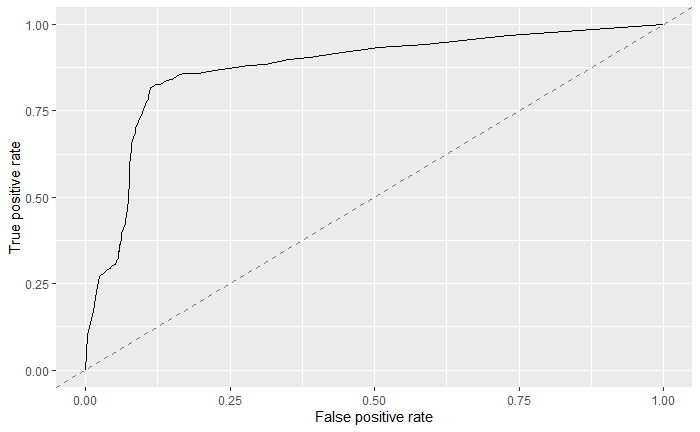

```r
library(ROCR)

#Train data

roc_obj_train_qdamlr = generateThreshVsPerfData(qda.predict.train, measures = list(fpr, tpr, mmce))
plotROCCurves(roc_obj_train_qdamlr)
```

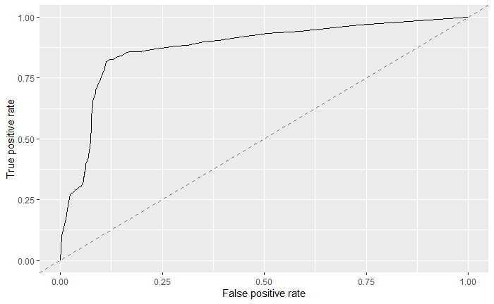

```r
#Test data

roc_obj_test_qdamlr = generateThreshVsPerfData(qda.predict.test, measures = list(fpr, tpr, mmce))
plotROCCurves(roc_obj_train_qdamlr)
```

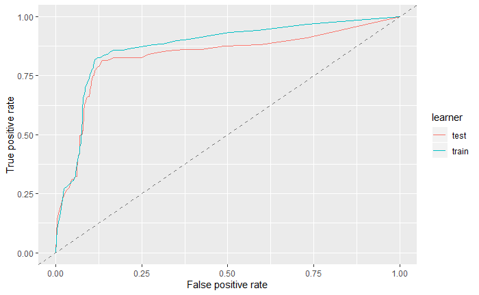

```r
#Combines AUC-ROC Curve of QDA train and test

df = generateThreshVsPerfData(list(train = qda.predict.train, test = qda.predict.test), measures = list(fpr, tpr))
plotROCCurves(df)
```

```r
results_train_qdamlr = data.frame(train_acc_qdamlr, train_sens_qdamlr, train_spec_qdamlr,as.numeric(mlr::performance(qda.predict.train, mlr::auc)))
names(results_train_qdamlr) = c("ACCURACY", "SENSITIVITY", "SPECIFICITY", "AUC-ROC")
results_test_qdamlr = data.frame(test_acc_qdamlr, test_sens_qdamlr, test_spec_qdamlr,as.numeric(mlr::performance(qda.predict.test, mlr::auc)) )
names(results_test_qdamlr) = c("ACCURACY", "SENSITIVITY", "SPECIFICITY" , "AUC-ROC")


df_fin =rbind(results_train_qdamlr, results_test_qdamlr)
row.names(df_fin) = c('QDA_train', 'QDA_test')
df_fin
```

|  | ACCURACY | SENSITIVITY | SPECIFICITY | AUC-ROC |
| --- | --- | --- | --- | --- |
| QDA_train | 0.8636948 | 0.5316456 | 0.9157164 | 0.8743175 |
| QDA_test | 0.8660000 | 0.5407407 | 0.9167630 | 0.8362250 |

```r
NA
```

### Build the QDA Model using qda function

```r
model_qda <- qda(traindata$Churn ~ . , traindata)

print(model_qda)
```

```
Call:
qda(traindata$Churn ~ ., data = traindata)

Prior probabilities of groups:
        0         1
0.8551222 0.1448778

Group means:
  AccountWeeks ContractRenewal    DataPlan   DataUsage CustServCalls     DayMins     DayCalls MonthlyCharge
0   0.02074025       0.1039082  0.04047668  0.03638995   -0.08417082 -0.09331117 -0.004573398   -0.03302403
1   0.01174568      -0.6523986 -0.26782186 -0.22626005    0.49873287  0.47709005  0.066597248    0.15278385
   OverageFee    RoamMins
0 -0.03265807 -0.05429375
1  0.22898580  0.12747922
```

### Predict on train data using the above QDA model

```r
qda.train <- predict(model_qda)

traindata$predict.class=qda.train$class

traindata$predict.posterior=qda.train$posterior


## Creating the confusion matrix
tabtrain=with(traindata,table(Churn,predict.class))
tabtrain
```

```
     predict.class
Churn    0    1
    0 1847  148
    1  170  168
```

```r
TN_train = tabtrain[1,1]
TP_train = tabtrain[2,2]
FN_train = tabtrain[2,1]
FP_train = tabtrain[1,2]

# Accuracy
train_acc_qda = (TN_train+TP_train)/(TN_train+TP_train+FN_train+FP_train)
train_acc_qda
```

```
[1] 0.8636948
```

```r
#Sensivity
train_sens_qda = TP_train/(TP_train+FN_train)
train_sens_qda
```

```
[1] 0.4970414
```

```r
#Specificity
train_spec_qda = TN_train/(TN_train+FP_train)
train_spec_qda
```

```
[1] 0.9258145
```

### Predict on test data using above QDA model

```r
qda.test <- predict(model_qda,testdata)

testdata$predict.class=qda.test$class

testdata$predict.posterior=qda.test$posterior


## Creating the confusion matrix
tabtest=with(testdata,table(Churn,predict.class))
tabtest
```

```
     predict.class
Churn   0   1
    0 790  65
    1  72  73
```

```r
TN_test = tabtest[1,1]
TP_test = tabtest[2,2]
FN_test = tabtest[2,1]
FP_test = tabtest[1,2]

#Accuracy
test_acc_qda = (TN_test+TP_test)/(TN_test+TP_test+FN_test+FP_test)
test_acc_qda
```

```
[1] 0.863
```

```r
#Sensivity
test_sens_qda = TP_test/(TP_test+FN_test)
test_sens_qda
```

```
[1] 0.5034483
```

```r
#Specificity
test_spec_qda = TN_test/(TN_test+FP_test)
test_spec_qda
```

```
[1] 0.9239766
```

### Draw the AUC-ROC Curve of QDA model with train and test data

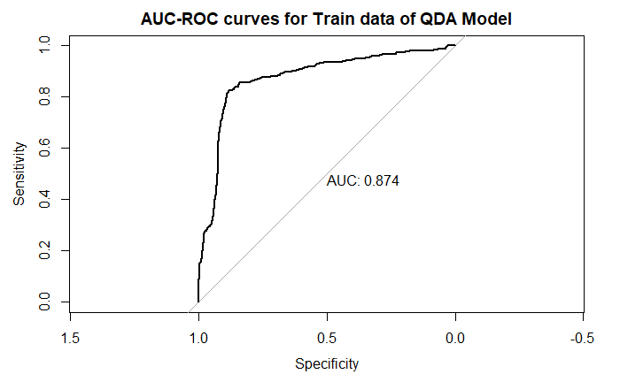

```r
library(pROC)
#Train data

roc_obj_train_qda = roc(traindata$Churn, traindata$predict.posterior[,2])
plot(roc_obj_train_qda, print.auc = T,main = "AUC-ROC curves for Train data of QDA Model")
```

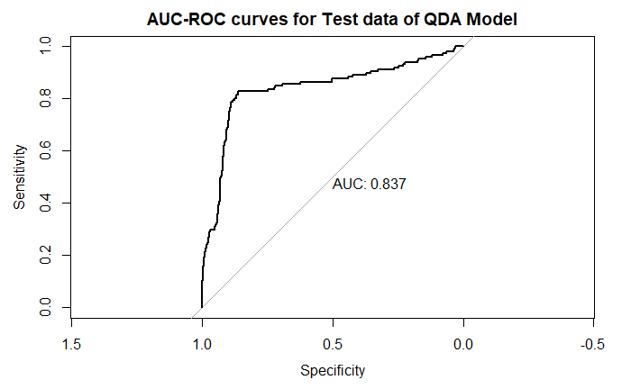

```r
#Test data

roc_obj_test_qda = roc(testdata$Churn, testdata$predict.posterior[,2])
plot(roc_obj_test_qda, print.auc = T,main = "AUC-ROC curves for Test data of QDA Model")
```

```r
#Combines AUC-ROC Curve of LDA train and test

plot(roc_obj_train_qda, main = "Combined AUC-ROC curves for Train and Test for QDA Model", col='blue',xlab = "1 - Specificity")
plot(roc_obj_test_qda,add=TRUE, col='red')
```

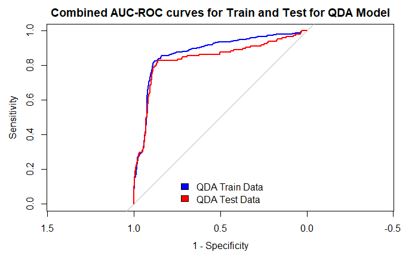

```r
legend('bottom', c("QDA Train Data", "QDA Test Data" ), fill = c('blue','red'), bty='n')
```

### Comparison of all performace measure of QDA model

```r
results_train_qda = data.frame(train_acc_qda, train_sens_qda, train_spec_qda , as.numeric(roc_obj_train_qda$auc))
names(results_train_qda) = c("ACCURACY", "SENSITIVITY", "SPECIFICITY" , "AUC-ROC" )
results_test_qda = data.frame(test_acc_qda, test_sens_qda, test_spec_qda ,as.numeric(roc_obj_test_qda$auc) )
names(results_test_qda) = c("ACCURACY", "SENSITIVITY", "SPECIFICITY" , "AUC-ROC")


df_fin =rbind(results_train_qda, results_test_qda)
row.names(df_fin) = c('QDA_train', 'QDA_test')
df_fin
```

|  | ACCURACY | SENSITIVITY | SPECIFICITY | AUC-ROC |
| --- | --- | --- | --- | --- |
| QDA_train | 0.8636948 | 0.4970414 | 0.9258145 | 0.8743175 |
| QDA_test | 0.8630000 | 0.5034483 | 0.9239766 | 0.8371527 |

```r
NA
```

### Remove predicted score and class before running other models

```r
traindata$predict.class = NULL
traindata$predict.posterior = NULL
testdata$predict.class = NULL
testdata$predict.posterior = NULL
```

```r
head(traindata)
```

|  | AccountWeeks | ContractRenewal | DataPlan | DataUsage | CustServCalls | DayMins | DayCalls | MonthlyCharge | OverageFee | RoamMins | Churn |
| --- | --- | --- | --- | --- | --- | --- | --- | --- | --- | --- | --- |
| 1 | 0.6763880 | 0.3275313 | 1.6168435 | 1.4799817 | -0.4278678 | 1.56653190 | 0.4765716 | 1.99042837 | -0.07157286 | -0.08499548 | 0 |
| 3 | 0.9023931 | 0.3275313 | -0.6183035 | -0.6415457 | -1.1880402 | 1.16812837 | 0.6758832 | -0.26209377 | -1.57410948 | 0.70301543 | 0 |
| 4 | -0.4285260 | -3.0522270 | -0.6183035 | -0.6415457 | 0.3323046 | 2.19626650 | -1.4667158 | 0.04230112 | -2.74143452 | -1.30283051 | 0 |
| 7 | 0.5006062 | 0.3275313 | 1.6168435 | 0.9535286 | 1.0924770 | 0.70546621 | -0.6196418 | 1.88693411 | 2.90983839 | -0.98046241 | 0 |
| 8 | 1.1535099 | -3.0522270 | -0.6183035 | -0.6415457 | -1.1880402 | -0.41814190 | -1.0680928 | -1.23615739 | -1.92903939 | -1.12373712 | 0 |
| 9 | 0.4001595 | 0.3275313 | -0.6183035 | -0.4922530 | -0.4278678 | 0.08674736 | -0.1711908 | 0.46236606 | 2.96899337 | -0.55063828 | 0 |

```r
head(testdata)
```

|  | AccountWeeks | ContractRenewal | DataPlan | DataUsage | CustServCalls | DayMins | DayCalls | MonthlyCharge | OverageFee | RoamMins | Churn |
| --- | --- | --- | --- | --- | --- | --- | --- | --- | --- | --- | --- |
| 2 | 0.1490427 | 0.3275313 | 1.6168435 | 2.2657325 | -0.4278678 | -0.3336877 | 1.1243341 | 1.56427553 | -0.1070658 | 1.2402956 | 0 |
| 5 | -0.6545311 | -3.0522270 | -0.6183035 | -0.6415457 | 1.0924770 | -0.2400537 | 0.6260553 | -0.93176251 | -1.0377709 | -0.0491768 | 0 |
| 6 | 0.4252712 | -3.0522270 | -0.6183035 | -0.6415457 | -1.1880402 | 0.8009362 | -0.1213630 | 0.04230112 | 0.3858924 | -1.4102865 | 0 |
| 11 | -0.9056479 | 0.3275313 | -0.6183035 | -0.4136779 | 1.8526494 | -0.9303750 | 1.8219245 | -0.69433450 | 0.5436390 | 0.8821088 | 1 |
| 13 | 1.6808552 | 0.3275313 | -0.6183035 | -0.6415457 | -0.4278678 | -0.9358829 | -0.2210187 | -1.54055228 | -1.8935464 | 0.3448287 | 0 |
| 18 | -0.2025208 | 0.3275313 | -0.6183035 | -0.6415457 | 1.0924770 | 0.2005769 | 0.6758832 | -0.32297274 | 0.3385684 | -0.7655503 | 0 |

```r
NA
```

### Build SVM model on Train dataset

```r
library(e1071)


model_svm <- svm(traindata$Churn ~ . , data = traindata, kernel="linear", scale = FALSE)

model_svm
```

```
Call:
svm(formula = traindata$Churn ~ ., data = traindata, kernel = "linear", scale = FALSE)


Parameters:
   SVM-Type:  C-classification
 SVM-Kernel:  linear
       cost:  1

Number of Support Vectors:  874
```

### Prediction on Train dataset using SVM Model

```r
traindata$predict.class <- predict(model_svm,traindata, decision.values=TRUE)

traindata$decision.values <- attributes(traindata$predict.class)$decision.values


## Creating the confusion matrix
tabtrain=with(traindata,table(Churn,predict.class))
tabtrain
```

```
     predict.class
Churn    0    1
    0 1995    0
    1  338    0
```

```r
TN_train = tabtrain[1,1]
TP_train = tabtrain[2,2]
FN_train = tabtrain[2,1]
FP_train = tabtrain[1,2]

# Accuracy
train_acc_svm = (TN_train+TP_train)/(TN_train+TP_train+FN_train+FP_train)
train_acc_svm
```

```
[1] 0.8551222
```

```r
#Sensivity
train_sens_svm = TP_train/(TP_train+FN_train)
train_sens_svm
```

```
[1] 0
```

```r
#Specificity
train_spec_svm = TN_train/(TN_train+FP_train)
train_spec_svm
```

```
[1] 1
```

### Prediction on Test dataset using SVM Model

```r
testdata$predict.class <- predict(model_svm , newdata = testdata , decision.values=TRUE)

testdata$decision.values <- attributes(testdata$predict.class)$decision.values

## Creating the confusion matrix
tabtest=with(testdata,table(Churn,predict.class))
tabtest
```

```
     predict.class
Churn   0   1
    0 855   0
    1 145   0
```

```r
TN_test = tabtest[1,1]
TP_test = tabtest[2,2]
FN_test = tabtest[2,1]
FP_test = tabtest[1,2]

#Accuracy
test_acc_svm = (TN_test+TP_test)/(TN_test+TP_test+FN_test+FP_test)
test_acc_svm
```

```
[1] 0.855
```

```r
#Sensivity
test_sens_svm = TP_test/(TP_test+FN_test)
test_sens_svm
```

```
[1] 0
```

```r
#Specificity
test_spec_svm = TN_test/(TN_test+FP_test)
test_spec_svm
```

```
[1] 1
```

### AUC-ROC Curve for SVM model on Train and Test dataset

```
Deprecated use a matrix as predictor. Unexpected results may be produced, please pass a numeric vector.Setting direction: controls > cases
```

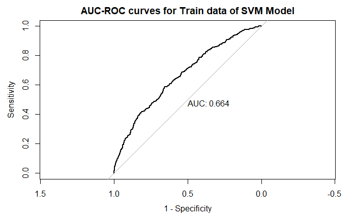

```r
library(pROC)

#Train data - Plot ROC curve
roc_obj_train_svm <- plot.roc(as.numeric(traindata$Churn), traindata$decision.values, main = "AUC-ROC curves for Train data of SVM Model" , xlab = "1 - Specificity", print.auc=TRUE)
```

```r
roc_obj_train_svm
```

```
Call:
plot.roc.default(x = as.numeric(traindata$Churn), predictor = traindata$decision.values,     main = "AUC-ROC curves for Train data of SVM Model", xlab = "1 - Specificity",     print.auc = TRUE)

Data: traindata$decision.values in 1995 controls (as.numeric(traindata$Churn) 1) > 338 cases (as.numeric(traindata$Churn) 2).
Area under the curve: 0.6641
```

```
Deprecated use a matrix as predictor. Unexpected results may be produced, please pass a numeric vector.Setting direction: controls > cases
```

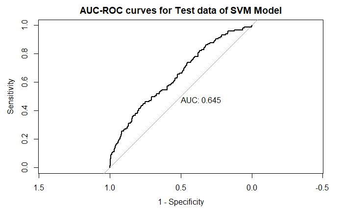

```r
#Test data - Plot ROC curve
roc_obj_test_svm <- plot.roc(as.numeric(testdata$Churn), testdata$decision.values, main = "AUC-ROC curves for Test data of SVM Model" , xlab = "1 - Specificity", print.auc=TRUE)
```

```r
roc_obj_test_svm
```

```
Call:
plot.roc.default(x = as.numeric(testdata$Churn), predictor = testdata$decision.values,     main = "AUC-ROC curves for Test data of SVM Model", xlab = "1 - Specificity",     print.auc = TRUE)

Data: testdata$decision.values in 855 controls (as.numeric(testdata$Churn) 1) > 145 cases (as.numeric(testdata$Churn) 2).
Area under the curve: 0.6452
```

```r
plot(roc_obj_train_svm, main = "Combined AUC-ROC curves for Train and Test for SVM Model", col='blue',xlab = "1 - Specificity")
plot(roc_obj_test_svm,add=TRUE, col='red')
```

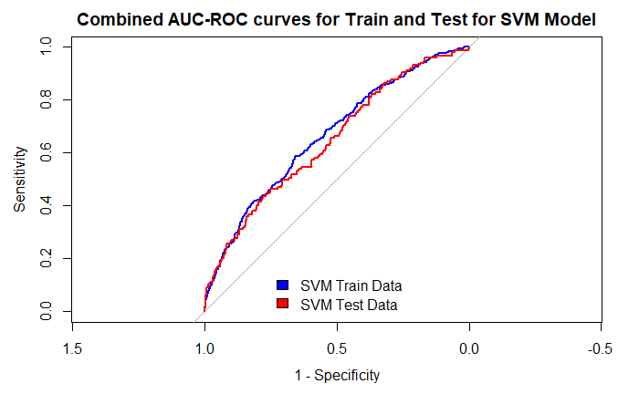

```r
legend('bottom', c("SVM Train Data", "SVM Test Data" ), fill = c('blue','red'), bty='n')
```

```r
NA
NA
```

### Comparison of all the performace measure of SVM Model on Train and Test dataset

```r
results_train_svm = data.frame(train_acc_svm, train_sens_svm, train_spec_svm , as.numeric(roc_obj_train_svm$auc))
names(results_train_svm) = c("ACCURACY", "SENSITIVITY", "SPECIFICITY" , "AUC-ROC" )
results_test_svm = data.frame(test_acc_svm, test_sens_svm, test_spec_svm ,as.numeric(roc_obj_test_svm$auc) )
names(results_test_svm) = c("ACCURACY", "SENSITIVITY", "SPECIFICITY" , "AUC-ROC")


df_fin =rbind(results_train_svm, results_test_svm)
row.names(df_fin) = c('SVM_Train', 'SVM_Test')
df_fin
```

|  | ACCURACY | SENSITIVITY | SPECIFICITY | AUC-ROC |
| --- | --- | --- | --- | --- |
| SVM_Train | 0.8551222 | 0 | 1 | 0.6640803 |
| SVM_Test | 0.8550000 | 0 | 1 | 0.6452027 |

### Remove predicted score and class before running other models

```r
traindata$predict.class = NULL
traindata$decision.values = NULL
testdata$predict.class = NULL
testdata$decision.values = NULL
```

```r
head(traindata)
```

|  | AccountWeeks | ContractRenewal | DataPlan | DataUsage | CustServCalls | DayMins | DayCalls | MonthlyCharge | OverageFee | RoamMins | Churn |
| --- | --- | --- | --- | --- | --- | --- | --- | --- | --- | --- | --- |
| 1 | 0.6763880 | 0.3275313 | 1.6168435 | 1.4799817 | -0.4278678 | 1.56653190 | 0.4765716 | 1.99042837 | -0.07157286 | -0.08499548 | 0 |
| 3 | 0.9023931 | 0.3275313 | -0.6183035 | -0.6415457 | -1.1880402 | 1.16812837 | 0.6758832 | -0.26209377 | -1.57410948 | 0.70301543 | 0 |
| 4 | -0.4285260 | -3.0522270 | -0.6183035 | -0.6415457 | 0.3323046 | 2.19626650 | -1.4667158 | 0.04230112 | -2.74143452 | -1.30283051 | 0 |
| 7 | 0.5006062 | 0.3275313 | 1.6168435 | 0.9535286 | 1.0924770 | 0.70546621 | -0.6196418 | 1.88693411 | 2.90983839 | -0.98046241 | 0 |
| 8 | 1.1535099 | -3.0522270 | -0.6183035 | -0.6415457 | -1.1880402 | -0.41814190 | -1.0680928 | -1.23615739 | -1.92903939 | -1.12373712 | 0 |
| 9 | 0.4001595 | 0.3275313 | -0.6183035 | -0.4922530 | -0.4278678 | 0.08674736 | -0.1711908 | 0.46236606 | 2.96899337 | -0.55063828 | 0 |

```r
head(testdata)
```

|  | AccountWeeks | ContractRenewal | DataPlan | DataUsage | CustServCalls | DayMins | DayCalls | MonthlyCharge | OverageFee | RoamMins | Churn |
| --- | --- | --- | --- | --- | --- | --- | --- | --- | --- | --- | --- |
| 2 | 0.1490427 | 0.3275313 | 1.6168435 | 2.2657325 | -0.4278678 | -0.3336877 | 1.1243341 | 1.56427553 | -0.1070658 | 1.2402956 | 0 |
| 5 | -0.6545311 | -3.0522270 | -0.6183035 | -0.6415457 | 1.0924770 | -0.2400537 | 0.6260553 | -0.93176251 | -1.0377709 | -0.0491768 | 0 |
| 6 | 0.4252712 | -3.0522270 | -0.6183035 | -0.6415457 | -1.1880402 | 0.8009362 | -0.1213630 | 0.04230112 | 0.3858924 | -1.4102865 | 0 |
| 11 | -0.9056479 | 0.3275313 | -0.6183035 | -0.4136779 | 1.8526494 | -0.9303750 | 1.8219245 | -0.69433450 | 0.5436390 | 0.8821088 | 1 |
| 13 | 1.6808552 | 0.3275313 | -0.6183035 | -0.6415457 | -0.4278678 | -0.9358829 | -0.2210187 | -1.54055228 | -1.8935464 | 0.3448287 | 0 |
| 18 | -0.2025208 | 0.3275313 | -0.6183035 | -0.6415457 | 1.0924770 | 0.2005769 | 0.6758832 | -0.32297274 | 0.3385684 | -0.7655503 | 0 |

### Find the best cost and gamma value for tuning SVM Model

```r
#svm_tune <- tune.svm(Churn~., data = traindata, gamma = c(.5,1,2), cost = 2^(2:4))

svm_tune <- tune.svm(Churn~., data = traindata, gamma = 2^(-2:1), cost = 2^(-2:5))
summary(svm_tune)
```

```
Parameter tuning of ‘svm’:

- sampling method: 10-fold cross validation

- best parameters:
```

|  | gamma | cost |
| --- | --- | --- |
|  | 0.25 | 1 |

```
- best performance: 0.09431789

- Detailed performance results:
```

| gamma | cost | error | dispersion |
| --- | --- | --- | --- |
| 0.25 | 0.25 | 0.12173618 | 0.01559130 |
| 0.50 | 0.25 | 0.13416419 | 0.01877072 |
| 1.00 | 0.25 | 0.14488097 | 0.02012022 |
| 2.00 | 0.25 | 0.14488097 | 0.02012022 |
| 0.25 | 0.50 | 0.10588753 | 0.01818189 |
| 0.50 | 0.50 | 0.12131066 | 0.01769044 |
| 1.00 | 0.50 | 0.13845053 | 0.01887998 |
| 2.00 | 0.50 | 0.14488097 | 0.02012022 |
| 0.25 | 1.00 | 0.09431789 | 0.01861616 |
| 0.50 | 1.00 | 0.10888816 | 0.01969678 |

[output cut: 22 more lines]

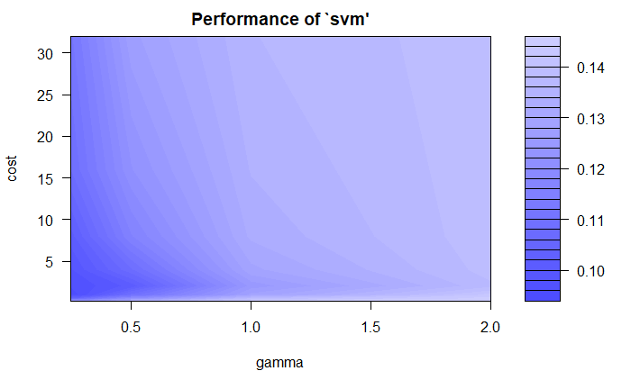

```r
plot(svm_tune)
```

```r
NA
NA
```

### Build the SVM Model with some Tuned parameters using kernal as radial

```r
model_svm_tune_radial <- svm(Churn ~ ., data=traindata, kernel="radial", cost=2, gamma=0.25)
summary(model_svm_tune_radial)
```

```
Call:
svm(formula = Churn ~ ., data = traindata, kernel = "radial", cost = 2, gamma = 0.25)


Parameters:
   SVM-Type:  C-classification
 SVM-Kernel:  radial
       cost:  2

Number of Support Vectors:  786

 ( 509 277 )


Number of Classes:  2

Levels:
 0 1
```

### Prediction on Train dataset using Tuned SVM Model ( kernel = radial )

```r
traindata$predict.class <- predict(model_svm_tune_radial,traindata, decision.values=TRUE)

traindata$decision.values <- attributes(traindata$predict.class)$decision.values


## Creating the confusion matrix
tabtrain=with(traindata,table(Churn,predict.class))
tabtrain
```

```
     predict.class
Churn    0    1
    0 1983   12
    1   79  259
```

```r
TN_train = tabtrain[1,1]
TP_train = tabtrain[2,2]
FN_train = tabtrain[2,1]
FP_train = tabtrain[1,2]

# Accuracy
train_acc_svm_tune_radial = (TN_train+TP_train)/(TN_train+TP_train+FN_train+FP_train)
train_acc_svm_tune_radial
```

```
[1] 0.9609944
```

```r
#Sensivity
train_sens_svm_tune_radial = TP_train/(TP_train+FN_train)
train_sens_svm_tune_radial
```

```
[1] 0.7662722
```

```r
#Specificity
train_spec_svm_tune_radial = TN_train/(TN_train+FP_train)
train_spec_svm_tune_radial
```

```
[1] 0.993985
```

```r
#table(Actual=traindata$Churn,predicted=svm_train_prediction)
```

### Prediction on Test dataset using Tuned SVM Model ( kernel = radial )

```r
testdata$predict.class <- predict(model_svm_tune_radial,testdata, decision.values=TRUE)

testdata$decision.values <- attributes(testdata$predict.class)$decision.values


## Creating the confusion matrix
tabtest=with(testdata,table(Churn,predict.class))
tabtest
```

```
     predict.class
Churn   0   1
    0 843  12
    1  63  82
```

```r
TN_test = tabtest[1,1]
TP_test = tabtest[2,2]
FN_test = tabtest[2,1]
FP_test = tabtest[1,2]

# Accuracy
test_acc_svm_tune_radial = (TN_test+TP_test)/(TN_test+TP_test+FN_test+FP_test)
test_acc_svm_tune_radial
```

```
[1] 0.925
```

```r
#Sensivity
test_sens_svm_tune_radial = TP_test/(TP_test+FN_test)
test_sens_svm_tune_radial
```

```
[1] 0.5655172
```

```r
#Specificity
test_spec_svm_tune_radial = TN_test/(TN_test+FP_test)
test_spec_svm_tune_radial
```

```
[1] 0.9859649
```

```r
#table(Actual=testdata$Churn,predicted=svm_test_prediction)
```

### AUC-ROC Curve for SVM model on Train and Test dataset

```
Deprecated use a matrix as predictor. Unexpected results may be produced, please pass a numeric vector.Setting direction: controls > cases
```

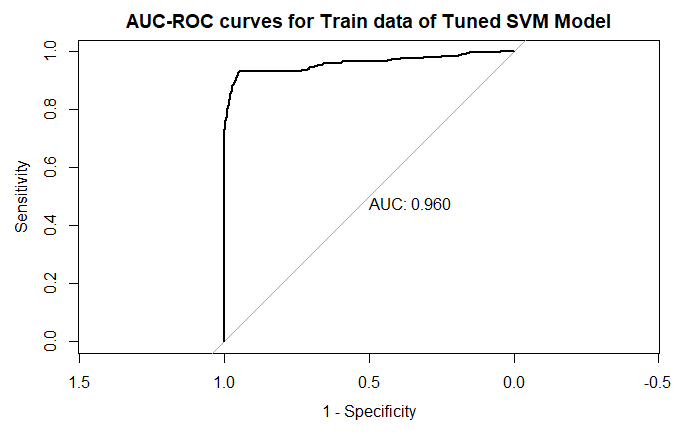

```r
library(pROC)

#Train data - Plot ROC curve
roc_obj_train_svm_tune_radial <- plot.roc(as.numeric(traindata$Churn), traindata$decision.values, main = "AUC-ROC curves for Train data of Tuned SVM Model" , xlab = "1 - Specificity", print.auc=TRUE)
```

```r
roc_obj_train_svm_tune_radial
```

```
Call:
plot.roc.default(x = as.numeric(traindata$Churn), predictor = traindata$decision.values,     main = "AUC-ROC curves for Train data of Tuned SVM Model",     xlab = "1 - Specificity", print.auc = TRUE)

Data: traindata$decision.values in 1995 controls (as.numeric(traindata$Churn) 1) > 338 cases (as.numeric(traindata$Churn) 2).
Area under the curve: 0.9598
```

```
Deprecated use a matrix as predictor. Unexpected results may be produced, please pass a numeric vector.Setting direction: controls > cases
```

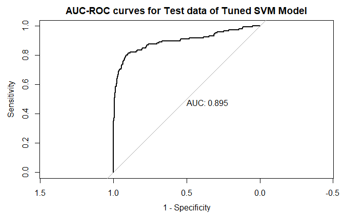

```r
#Test data - Plot ROC curve
roc_obj_test_svm_tune_radial <- plot.roc(as.numeric(testdata$Churn), testdata$decision.values, main = "AUC-ROC curves for Test data of Tuned SVM Model" , xlab = "1 - Specificity", print.auc=TRUE)
```

```r
roc_obj_test_svm_tune_radial
```

```
Call:
plot.roc.default(x = as.numeric(testdata$Churn), predictor = testdata$decision.values,     main = "AUC-ROC curves for Test data of Tuned SVM Model",     xlab = "1 - Specificity", print.auc = TRUE)

Data: testdata$decision.values in 855 controls (as.numeric(testdata$Churn) 1) > 145 cases (as.numeric(testdata$Churn) 2).
Area under the curve: 0.8951
```

```r
plot(roc_obj_train_svm_tune_radial, main = "Combined AUC-ROC curves for Train and Test for Tuned SVM Model(kernal=radial)", col='blue',xlab = "1 - Specificity")
plot(roc_obj_test_svm_tune_radial,add=TRUE, col='red')
```

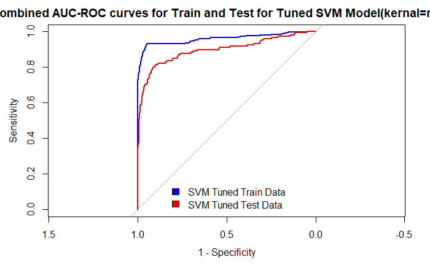

```r
legend('bottom', c("SVM Tuned Train Data", "SVM Tuned Test Data" ), fill = c('blue','red'), bty='n')
```

```r
NA
NA
```

### Comparison of all the performace measure of Tuned SVM Model using radial kernal on Train and Test dataset

```r
results_train_svm_tune_radial = data.frame(train_acc_svm_tune_radial, train_sens_svm_tune_radial, train_spec_svm_tune_radial , as.numeric(roc_obj_train_svm_tune_radial$auc))
names(results_train_svm_tune_radial) = c("ACCURACY", "SENSITIVITY", "SPECIFICITY" , "AUC-ROC" )
results_test_svm_tune_radial = data.frame(test_acc_svm_tune_radial, test_sens_svm_tune_radial, test_spec_svm_tune_radial ,as.numeric(roc_obj_test_svm_tune_radial$auc) )
names(results_test_svm_tune_radial) = c("ACCURACY", "SENSITIVITY", "SPECIFICITY" , "AUC-ROC")


df_fin =rbind(results_train_svm_tune_radial, results_test_svm_tune_radial)
row.names(df_fin) = c('SVM_Tuned_Train_Radial', 'SVM_Tuned_Test_Radial')
df_fin
```

|  | ACCURACY | SENSITIVITY | SPECIFICITY | AUC-ROC |
| --- | --- | --- | --- | --- |
| SVM_Tuned_Train_Radial | 0.9609944 | 0.7662722 | 0.9939850 | 0.9597885 |
| SVM_Tuned_Test_Radial | 0.9250000 | 0.5655172 | 0.9859649 | 0.8950918 |

```r
### Remove predicted score and class before running other models
traindata$predict.class = NULL
traindata$decision.values = NULL
testdata$predict.class = NULL
testdata$decision.values = NULL
```

```r
head(traindata)
```

|  | AccountWeeks | ContractRenewal | DataPlan | DataUsage | CustServCalls | DayMins | DayCalls | MonthlyCharge | OverageFee | RoamMins | Churn |
| --- | --- | --- | --- | --- | --- | --- | --- | --- | --- | --- | --- |
| 1 | 0.6763880 | 0.3275313 | 1.6168435 | 1.4799817 | -0.4278678 | 1.56653190 | 0.4765716 | 1.99042837 | -0.07157286 | -0.08499548 | 0 |
| 3 | 0.9023931 | 0.3275313 | -0.6183035 | -0.6415457 | -1.1880402 | 1.16812837 | 0.6758832 | -0.26209377 | -1.57410948 | 0.70301543 | 0 |
| 4 | -0.4285260 | -3.0522270 | -0.6183035 | -0.6415457 | 0.3323046 | 2.19626650 | -1.4667158 | 0.04230112 | -2.74143452 | -1.30283051 | 0 |
| 7 | 0.5006062 | 0.3275313 | 1.6168435 | 0.9535286 | 1.0924770 | 0.70546621 | -0.6196418 | 1.88693411 | 2.90983839 | -0.98046241 | 0 |
| 8 | 1.1535099 | -3.0522270 | -0.6183035 | -0.6415457 | -1.1880402 | -0.41814190 | -1.0680928 | -1.23615739 | -1.92903939 | -1.12373712 | 0 |
| 9 | 0.4001595 | 0.3275313 | -0.6183035 | -0.4922530 | -0.4278678 | 0.08674736 | -0.1711908 | 0.46236606 | 2.96899337 | -0.55063828 | 0 |

```r
head(testdata)
```

|  | AccountWeeks | ContractRenewal | DataPlan | DataUsage | CustServCalls | DayMins | DayCalls | MonthlyCharge | OverageFee | RoamMins | Churn |
| --- | --- | --- | --- | --- | --- | --- | --- | --- | --- | --- | --- |
| 2 | 0.1490427 | 0.3275313 | 1.6168435 | 2.2657325 | -0.4278678 | -0.3336877 | 1.1243341 | 1.56427553 | -0.1070658 | 1.2402956 | 0 |
| 5 | -0.6545311 | -3.0522270 | -0.6183035 | -0.6415457 | 1.0924770 | -0.2400537 | 0.6260553 | -0.93176251 | -1.0377709 | -0.0491768 | 0 |
| 6 | 0.4252712 | -3.0522270 | -0.6183035 | -0.6415457 | -1.1880402 | 0.8009362 | -0.1213630 | 0.04230112 | 0.3858924 | -1.4102865 | 0 |
| 11 | -0.9056479 | 0.3275313 | -0.6183035 | -0.4136779 | 1.8526494 | -0.9303750 | 1.8219245 | -0.69433450 | 0.5436390 | 0.8821088 | 1 |
| 13 | 1.6808552 | 0.3275313 | -0.6183035 | -0.6415457 | -0.4278678 | -0.9358829 | -0.2210187 | -1.54055228 | -1.8935464 | 0.3448287 | 0 |
| 18 | -0.2025208 | 0.3275313 | -0.6183035 | -0.6415457 | 1.0924770 | 0.2005769 | 0.6758832 | -0.32297274 | 0.3385684 | -0.7655503 | 0 |

### Build the SVM Tuned model using kernel as polynomial

```r
model_svm_tune_poly <- svm(Churn ~ ., data=traindata, kernel="polynomial", cost=2, gamma=0.25)
summary(model_svm_tune_poly)
```

```
Call:
svm(formula = Churn ~ ., data = traindata, kernel = "polynomial", cost = 2, gamma = 0.25)


Parameters:
   SVM-Type:  C-classification
 SVM-Kernel:  polynomial
       cost:  2
     degree:  3
     coef.0:  0

Number of Support Vectors:  462

 ( 249 213 )


Number of Classes:  2

Levels:
 0 1
```

### Prediction on Train dataset using Tuned SVM Model ( kernel = polynomial)

```r
traindata$predict.class <- predict(model_svm_tune_poly,traindata, decision.values=TRUE)

traindata$decision.values <- attributes(traindata$predict.class)$decision.values


## Creating the confusion matrix
tabtrain=with(traindata,table(Churn,predict.class))
tabtrain
```

```
     predict.class
Churn    0    1
    0 1965   30
    1  111  227
```

```r
TN_train = tabtrain[1,1]
TP_train = tabtrain[2,2]
FN_train = tabtrain[2,1]
FP_train = tabtrain[1,2]

# Accuracy
train_acc_svm_tune_poly = (TN_train+TP_train)/(TN_train+TP_train+FN_train+FP_train)
train_acc_svm_tune_poly
```

```
[1] 0.9395628
```

```r
#Sensivity
train_sens_svm_tune_poly = TP_train/(TP_train+FN_train)
train_sens_svm_tune_poly
```

```
[1] 0.6715976
```

```r
#Specificity
train_spec_svm_tune_poly = TN_train/(TN_train+FP_train)
train_spec_svm_tune_poly
```

```
[1] 0.9849624
```

```r
#table(Actual=traindata$Churn,predicted=svm_train_prediction)
```

### Prediction on Test dataset using Tuned SVM Model ( kernal = polynomial)

```r
testdata$predict.class <- predict(model_svm_tune_poly,testdata, decision.values=TRUE)

testdata$decision.values <- attributes(testdata$predict.class)$decision.values


## Creating the confusion matrix
tabtest=with(testdata,table(Churn,predict.class))
tabtest
```

```
     predict.class
Churn   0   1
    0 836  19
    1  53  92
```

```r
TN_test = tabtest[1,1]
TP_test = tabtest[2,2]
FN_test = tabtest[2,1]
FP_test = tabtest[1,2]

# Accuracy
test_acc_svm_tune_poly = (TN_test+TP_test)/(TN_test+TP_test+FN_test+FP_test)
test_acc_svm_tune_poly
```

```
[1] 0.928
```

```r
#Sensivity
test_sens_svm_tune_poly = TP_test/(TP_test+FN_test)
test_sens_svm_tune_poly
```

```
[1] 0.6344828
```

```r
#Specificity
test_spec_svm_tune_poly = TN_test/(TN_test+FP_test)
test_spec_svm_tune_poly
```

```
[1] 0.9777778
```

```r
#table(Actual=testdata$Churn,predicted=svm_test_prediction)
```

### AUC-ROC Curve for SVM model on Train and Test dataset

```
Deprecated use a matrix as predictor. Unexpected results may be produced, please pass a numeric vector.Setting direction: controls > cases
```

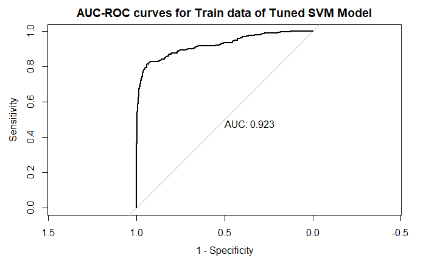

```r
library(pROC)

#Train data - Plot ROC curve
roc_obj_train_svm_tune_poly <- plot.roc(as.numeric(traindata$Churn), traindata$decision.values, main = "AUC-ROC curves for Train data of Tuned SVM Model" , xlab = "1 - Specificity", print.auc=TRUE)
```

```r
roc_obj_train_svm_tune_poly
```

```
Call:
plot.roc.default(x = as.numeric(traindata$Churn), predictor = traindata$decision.values,     main = "AUC-ROC curves for Train data of Tuned SVM Model",     xlab = "1 - Specificity", print.auc = TRUE)

Data: traindata$decision.values in 1995 controls (as.numeric(traindata$Churn) 1) > 338 cases (as.numeric(traindata$Churn) 2).
Area under the curve: 0.923
```

```
Deprecated use a matrix as predictor. Unexpected results may be produced, please pass a numeric vector.Setting direction: controls > cases
```

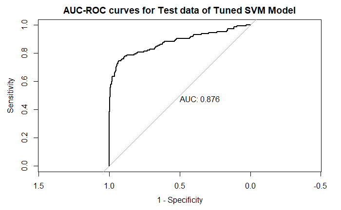

```r
#Test data - Plot ROC curve
roc_obj_test_svm_tune_poly <- plot.roc(as.numeric(testdata$Churn), testdata$decision.values, main = "AUC-ROC curves for Test data of Tuned SVM Model" , xlab = "1 - Specificity", print.auc=TRUE)
```

```r
roc_obj_test_svm_tune_poly
```

```
Call:
plot.roc.default(x = as.numeric(testdata$Churn), predictor = testdata$decision.values,     main = "AUC-ROC curves for Test data of Tuned SVM Model",     xlab = "1 - Specificity", print.auc = TRUE)

Data: testdata$decision.values in 855 controls (as.numeric(testdata$Churn) 1) > 145 cases (as.numeric(testdata$Churn) 2).
Area under the curve: 0.876
```

```r
plot(roc_obj_train_svm_tune_poly, main = "Combined AUC-ROC curves for Train and Test for Tuned SVM Model", col='blue',xlab = "1 - Specificity")
plot(roc_obj_test_svm_tune_poly,add=TRUE, col='red')
```

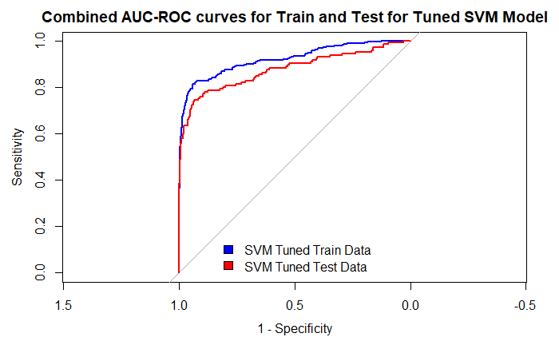

```r
legend('bottom', c("SVM Tuned Train Data", "SVM Tuned Test Data" ), fill = c('blue','red'), bty='n')
```

```r
NA
NA
```

### Comparison of all the performace measure of Tuned SVM Model on Train and Test dataset

```r
results_train_svm_tune_poly = data.frame(train_acc_svm_tune_poly, train_sens_svm_tune_poly, train_spec_svm_tune_poly , as.numeric(roc_obj_train_svm_tune_poly$auc))
names(results_train_svm_tune_poly) = c("ACCURACY", "SENSITIVITY", "SPECIFICITY" , "AUC-ROC" )
results_test_svm_tune_poly = data.frame(test_acc_svm_tune_poly, test_sens_svm_tune_poly, test_spec_svm_tune_poly ,as.numeric(roc_obj_test_svm_tune_poly$auc) )
names(results_test_svm_tune_poly) = c("ACCURACY", "SENSITIVITY", "SPECIFICITY" , "AUC-ROC")


df_fin =rbind(results_train_svm_tune_poly, results_test_svm_tune_poly)
row.names(df_fin) = c('SVM_Tuned_Train_Polynomial', 'SVM_Tuned_Test_Polynomial')
df_fin
```

|  | ACCURACY | SENSITIVITY | SPECIFICITY | AUC-ROC |
| --- | --- | --- | --- | --- |
| SVM_Tuned_Train_Polynomial | 0.9395628 | 0.6715976 | 0.9849624 | 0.9230191 |
| SVM_Tuned_Test_Polynomial | 0.9280000 | 0.6344828 | 0.9777778 | 0.8759508 |

## Comparing best of both the models - LDA and SVM with their performance - Accuracy , Sensitivity, Specificity and AUC-ROC Curve

```r
df_fin =rbind(results_train_ldamlr, results_test_ldamlr, results_train_qdamlr, results_test_qdamlr, results_train_svm_tune_poly,results_test_svm_tune_poly)
row.names(df_fin) = c('LDA_Train', 'LDA_Test','QDA_Train', 'QDA_Test','SVM_Tune_Train','SVM_Tune_Test')
#round(df_fin,2)

#install.packages("kableExtra")
library(kableExtra)
print("Model Performance Comparison Metrics ")
```

```
[1] "Model Performance Comparison Metrics "
```

```r
kable(round(df_fin,2)) %>%
    kable_styling(c("striped","bordered"))
```

|  | ACCURACY | SENSITIVITY | SPECIFICITY | AUC-ROC |
| --- | --- | --- | --- | --- |
| LDA_Train | 0.85 | 0.47 | 0.88 | 0.83 |
| LDA_Test | 0.85 | 0.47 | 0.88 | 0.83 |
| QDA_Train | 0.86 | 0.53 | 0.92 | 0.87 |
| QDA_Test | 0.87 | 0.54 | 0.92 | 0.84 |
| SVM_Tune_Train | 0.94 | 0.67 | 0.98 | 0.92 |
| SVM_Tune_Test | 0.93 | 0.63 | 0.98 | 0.88 |

```r
NA
```

## CONCLUSION

The dataset which we used in our analysis includes a list of service-related factors about existing customers and information about whether they have stayed or left the service provider. We have performed versions of 2 algorithms like LDA and SVM. By performing the fisher and mahalanobis LDA, we could understand the contribution of the factors which would impact the churn. From the above said models an increase in the below variables affects the probability of customer churn occurrence:

• monthly charge • data usage • contract renewal • day minutes • overage fee • customer service calls • roam min • day call

### Understanding the business through model deployment:

Let us understand the churn by looking at the variable importance mentioned above.

- Increase in the overage fee of a customer is often associated with strong customer dissatisfaction, as it is the fee which he/she is likely to pay to break the contract.
- If a customer has more data usage it may indicate that the customer could be persuaded by competitor providing data discounts offers and he/she may churn eventually.
- Also, more number of customer service calls, suggest the customer is unhappy and has lot of complaints to be resolved indicating eventual customer churn.
- Increase in the daytime calls and roaming minutes may indicate customers moving towards the competitor with better offers and services.
- There are also variables which explains less churn of customers, such as data plan renewal and contract renewal,which suggests more offers or services taken by customers indicating his/her satisfaction.
- However ,there seems to be counter-intuitive effect of monthly charge variable because when the monthly charge increases the churn reduces, which is likely to be caused by the collinearity between MonthlyCharge and DataUsage and between MonthlyCharge and DayMins. But, it does not necessarily impact predictive accuracy. Since, we rely upon the performance on the validation set to evaluate predictive accuracy of the model.

### Data Limitation and model comparison:

There was a limitation in converting the independent categorical variables into factors to perform LDA and also the limitation of partial fulfillment of the assumptions like normality and covariance. So, we went ahead and performed the models such as QDA and SVM and compared it with the LDA metric output.

### Comparing models:

Since, this is the churn prediction model, it is important that the model deployed considers sensitivity as an important performance metric .By comparing the models across, we could see that :

- Tuned SVM model gives out the best results in terms of the sensitivity without much overfitting of the model.
- LDA has lower sensitivity when compared to SVM, as it is affected by the covariance, normality of data.
- Because of the data skewness and noise , SVM has the advantage over LDA and QDA because we are using the kernels in SVM .
- But, we can still use the LDA for the explanatory power, since SVM with kernels behaves like a black box, which would not give us more information on the variable importance.

Thus, both the models help us to achieve good differentiation among the churn variable groups.